# Longitudinal Analysis of Engineering Leadership Competencies (2023 - 2026)

Irina Benedyk

2026-05-27

# Multi-Year Leadership Competency Analysis

“Engineering leadership consists of capabilities and values that transform technical people from individual contributors into those who can lead teams to deliver a complex multi-disciplinary product” © Gordon-MIT Engineering Leadership Program.

**Cohorts Analyzed:** Civil Engineering students (mostly juniors) from Spring 2023 to present.

**Course:** Introduction to Transportation System Analysis (for most students, this course is their first exposure to transportation engineering).

This report consolidates leadership self-evaluation data across multiple academic years. By tracking self-reported competencies at the beginning, middle, and end of the semester, we can evaluate the long-term impact of course activities—specifically weekly group assignments (WGAs) and the final team project—on student leadership development.

# Methodology

This study evaluates leadership competencies via self-assessment, based on a modified framework by Stevens et al. (2021). It adopts Huckabee’s (2023) definition of leadership: the ability to influence others to reach a specific goal.

**Survey Instrument**

Participants responded to the following prompt using a 5-point Likert scale (1: Poorly to 5: Excellently):

*“Indicate how well your previous education prepared you for your professional career and enhanced your ability relative to each of the following skills.”*

**Longitudinal Adjustments & Notes:**

- **Survey Frequency:** In 2023, data was only collected twice (Initial and Final). From 2024 onward, a mid-semester evaluation was added to isolate the impacts of Weekly Group Assignments (Initial vs. Mid) from the impacts of the intensive Final Project (Mid vs. Final).
- **Criteria Modification:** The “Business Concepts” criterion (evaluated in 2023-2024) was removed from the survey in 2025. To maintain consistency across all years in this longitudinal analysis, it has been excluded from the data and graphs below.

**Evaluated Leadership Dimensions**

- **Leading Teams:** Running meetings and adjusting to personality types.
- **Strategic Thinking:** Using mission and vision statements effectively.
- **Teamwork:** Contributing to high-performing teams.
- **Project Management:** Applying formal processes to technical projects.
- **Feedback:** Mastering the art of professional critique.
- **Self-Reflection:** Ongoing evaluation of leadership growth.
- **Ethical Practice:** Navigating ethical issues and decision-making.
- **Innovation:** Fostering creative team cultures.
- **Global Competencies:** Navigating cross-cultural environments and reducing bias.
- **Emotional Intelligence:** Managing conflict and emotional regulation.
- **Communication:** Tailoring professional writing and speaking to audiences.
- **Initiative:** Taking ownership of new challenges and responsibilities.

# Initial Self-Evaluation Trends (Incoming Cohort Confidence)

This chart illustrates the baseline confidence levels of students entering the course each year. Tracking this allows us to observe shifts in the foundational skills of incoming classes over time. *Spring 2023 cohort* demonstrated higher incoming confidence in evaluated criterion. This can be attributed to the fact, that during that year, initial evaluation was conducted ~1 month into the course (not in the first week of class as it was done in other years). However, the fact that final self-evaluation for *Spring 2023 cohort* is also higher, suggests that it can be other interacting factors. Note, as the majority of students who are taking this course are juniors, most of them started at **Fall 2020**.

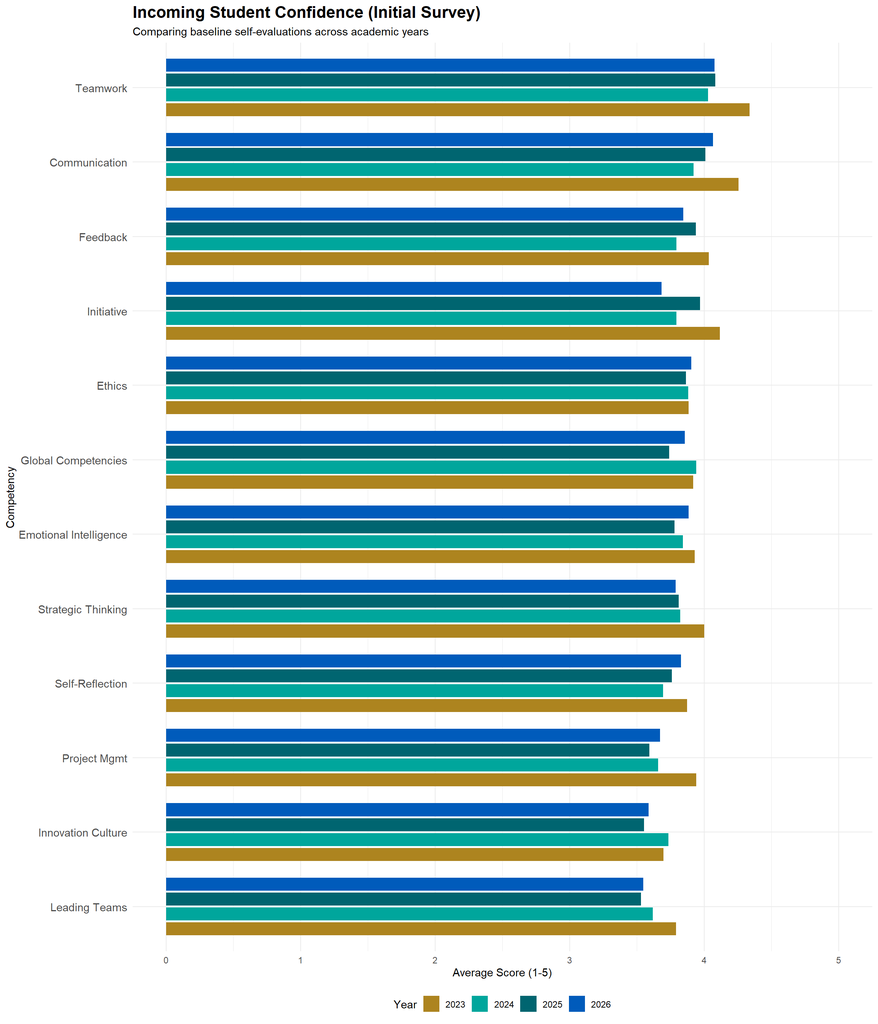

# Final Self-Evaluation Trends (Post-Curriculum Confidence)

This chart displays the ending confidence levels of students after completing the full curriculum, including WGAs and the final project.

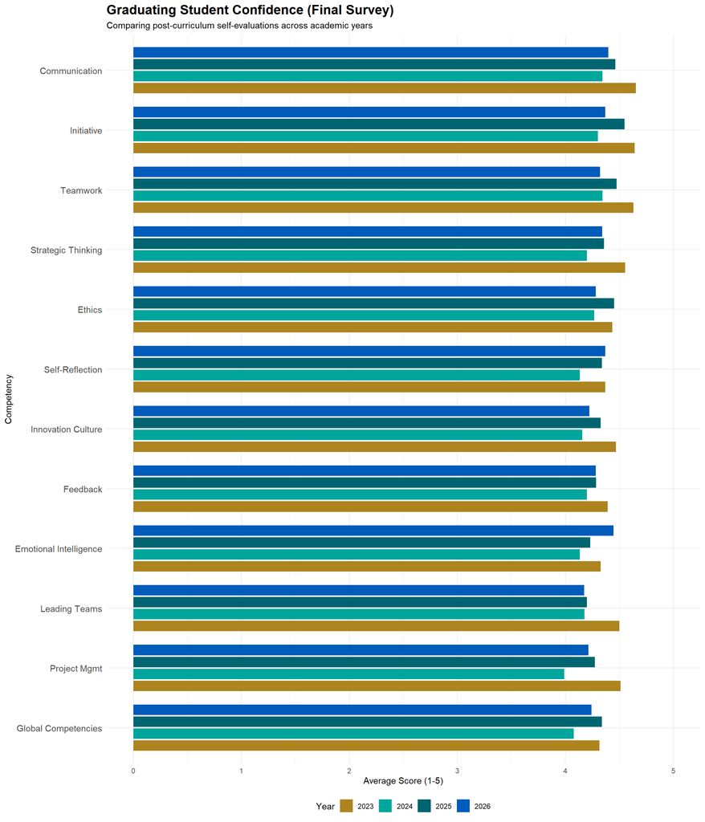

# Magnitude of Growth (Final vs. Initial)

This visualization highlights the absolute growth (Delta) for each skill. By subtracting the initial scores from the final scores, we can identify which competencies see the greatest developmental impact from the course year over year.

Few observations:

- Spring 2024 cohort demonstrated lowers perceived growth comparing to others (majority of students started education in Fall 2021).
- Innovation culture is leading in perceived growth for 2025 and 2023 cohorts.

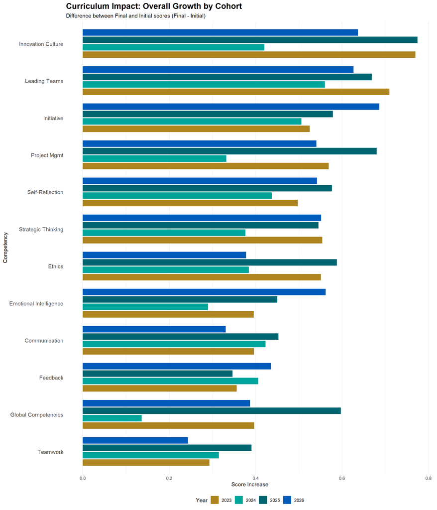

# Statistical Significance of Growth (Before vs. After)

To ensure the observed growth is statistically valid, an independent two-sample t-test was conducted for each competency, comparing the Initial distribution of scores to the Final distribution of scores for each year.

The chart below maps the average starting dot and ending dot for every skill, connected by a line.

The resulting p-value significance is annotated directly on the graph.

(3 stars for $p < 0.001$, 2 stars for $p < 0.01$, 1 star for $p < 0.05$, and $ns$ for not significant)

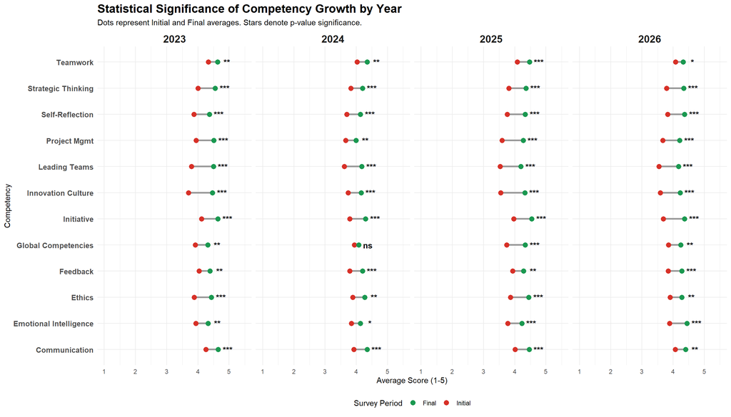